# CE1 Filippone Pozzoli

Lara-Cristina

11/26/2022

## THE PERCEPTION OF CLIMATE CHANGE: ARE YOUNG PEOPLE MORE WORRIED?

## Introduction

Climate change is not only an issue that is putting our planet and our survival in danger, but it can also have a negative impact on mental health. In fact, there is a specific term for mental health issues related to the climate crisis: “eco-anxiety”, defined as anxiety or worry one might feel about climate change and its effects (Clayton, 2020). Some subjects may be more prone than others to experience such mental distress. It seems logic to think that young people probably feel more anxious about climate change, because they will be the ones dealing with its consequences for the longer time and because their future is at stake. Several studies support this hypothesis: children and young people seem to be more aware of the danger of the climate crisis and tend to experience related anxiety, depression and pessimistic views (Susteren & Al-Delaimy, 2020).

In our research we tried to verify this hypothesis using the 2016 dataset from the European Social Survey, which contained some questions related to climate change and to its perception. Our goal was to understand whether there is a correlation between age of the respondents and attitude towards global warming.

## Our Variables

To carry out our analysis, we decided to use the variables “agea” and “wrclmch” from our original dataset.

- The variable “agea” was a quantitative variable referring to the respondents’ age, which we recoded into a categorical one, called “Age”. This way we divided the repondents into three groups: under 30, from 30 to 60 and over 60.
- The variable “wrclmch” was a categorical variable to measure the level of concern towards climate change. The possible answers ranged from ‘Not at all worried’ to ‘Extremely worried’. We recoded it in order to have just three cathegories: ‘Not worried’, ‘Somewhat worried’, ‘Worried’.

## Statistical analysis

```
##
##
##    Cell Contents
## |-------------------------|
## |                       N |
## | Chi-square contribution |
## |           N / Row Total |
## |           N / Col Total |
## |         N / Table Total |
## |-------------------------|
##
##
## Total Observations in Table:  42517
##
##
##                      | data$global_warming_attitude
##             data$age |      Not Worried | Somewhat worried |          Worried |        Row Total |
## ---------------------|------------------|------------------|------------------|------------------|
##          1. Under 30 |             2041 |             3491 |             2232 |             7764 |
##                      |            0.343 |            2.836 |            2.583 |                  |
##                      |            0.263 |            0.450 |            0.287 |            0.183 |
##                      |            0.185 |            0.177 |            0.189 |                  |
##                      |            0.048 |            0.082 |            0.052 |                  |
## ---------------------|------------------|------------------|------------------|------------------|
## 2. Between 30 and 60 |             5261 |            10282 |             6197 |            21740 |
##                      |           25.657 |            4.999 |            4.039 |                  |
##                      |            0.242 |            0.473 |            0.285 |            0.511 |
##                      |            0.477 |            0.523 |            0.525 |                  |
##                      |            0.124 |            0.242 |            0.146 |                  |
## ---------------------|------------------|------------------|------------------|------------------|
##           3. Over 60 |             3731 |             5897 |             3385 |            13013 |
##                      |           37.148 |            2.526 |           14.740 |                  |
##                      |            0.287 |            0.453 |            0.260 |            0.306 |
##                      |            0.338 |            0.300 |            0.287 |                  |
##                      |            0.088 |            0.139 |            0.080 |                  |
## ---------------------|------------------|------------------|------------------|------------------|
##         Column Total |            11033 |            19670 |            11814 |            42517 |
##                      |            0.259 |            0.463 |            0.278 |                  |
## ---------------------|------------------|------------------|------------------|------------------|
##
##
```

To analyze our two categorical variables we created a contingency table. As we can see from the table, the group “Between 30 and 60” is actually the one with the lowest percentage of respondents who answered “Not worried”, and the one with the highest percentage of respondents who answered “Somewhat worried”. The “Over 60” group is the one with the lowest percentage of respondents who answered “Worried”, which is about 2% lower than respondents from other age groups.

## Chi-square test

```
##
##  Pearson's Chi-squared test
##
## data:  data$age and data$global_warming_attitude
## X-squared = 94.87, df = 4, p-value < 0.00000000000000022
```

Then we executed a chi-square test to know if the results are significant. The value of the chi-square is very high and the P-value very small. Therefore our results are significant and we can reject the null hypothesis of independence between the two variables.

## Plot

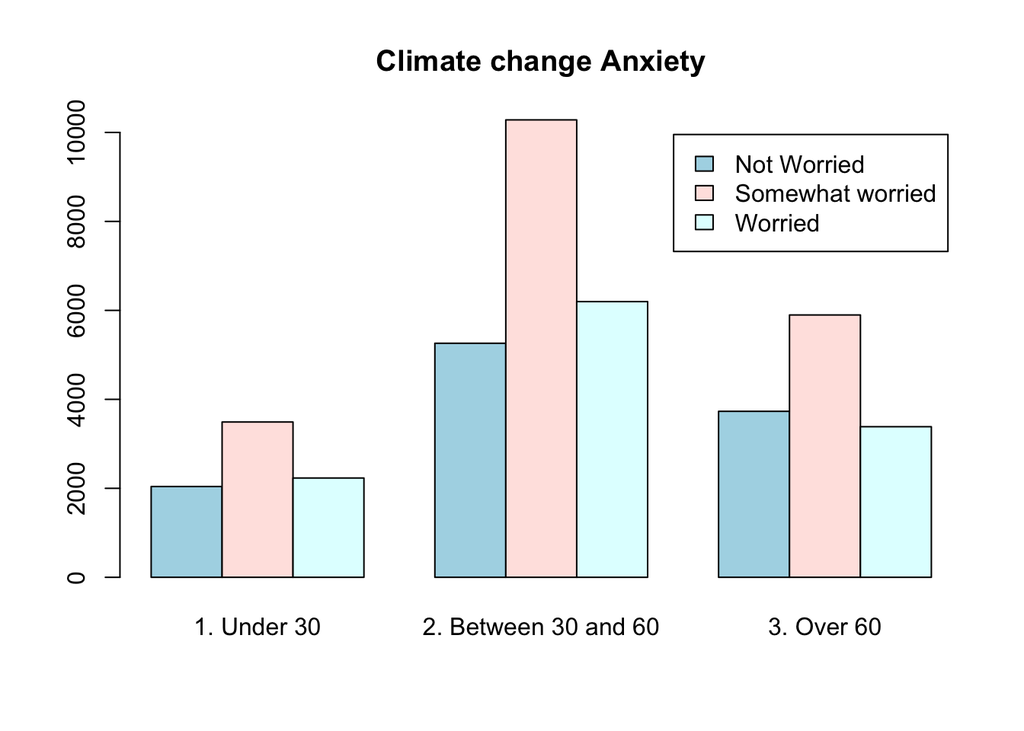

## Conclusions

Our analysis suggests that there is a correlation between age and attitude towards global warming. The group “Over 60” shows a lower level of awareness in comparison to the younger respondents. In particular the percentage of “Not worried” respondents is the highest (28.7%). Even if the differences are not so evident, the chi-square test suggests a high level of significance.

## Bibliography

Susteren, L. V., & Al-Delaimy, W. K. (2020). Psychological impacts of climate change and recommendations. In Health of People, Health of Planet and Our Responsibility (pp. 177-192). Springer, Cham.

Clayton, S. (2020). Climate anxiety: Psychological responses to climate change. Journal of anxiety disorders, 74, 102263.